# ANOVA - Repeated Measurs

Manfred Brill

Sommersemester 2021

# 1 ANOVA für repeated measures

Mit *repeated measures ANOVA* analysiert man Daten bei denen Subjekte im Experiment mehrfach vermessen oder erfasst werden. Eine andere Bezeichnung dafür ist *within-subjects ANOVA*. Mit *within-subject* ist gemeint, das ein Merkmal der identischen Individuen zu mehreren Zeitpunkten erfasst werden. Wir hatten beim Thema t-Test bereits verbundene oder gepaarte Tests durchgeführt - jetzt untersuchen wir den analogen Fall mit ANOVA.

Wir konzentrieren uns auf *one-way repeated measures*. Die Ausweitung auf zweifaktorielle Varianzanalyse oder noch mehr Faktoren können aber analog bearbeitet werden. Wieder verwenden wir die Packages *rstatix*, *ggpubr* und *datarium*.

In diesem Dokument konzentrieren wir uns auf die Durchführung der Tests. Mehr zu Voraussetzungen für die Durchführung der Tests und zu den Verfahren findet man in (Kassambara 2019) und online auf (Datanovia 2021).

# 2 One-way repeated measures ANOVA

## 2.1 Der Datensatz

Als Datensatz verwenden wir *selfesteem* aus dem Package *datarium*. Der Hilfetext zu diesem Datensatz gibt Auskunft über den Inhalt der Daten:

“ *The dataset contains 10 individuals’ self-esteem score on three time points during a specific diet to determine whether their self-esteem improved.* ”

Tabelle 1: Die ersten drei Zeilen des Datensatzes selfesteem

| id | t1 | t2 | t3 |
| --- | --- | --- | --- |
| 1 | 4.005 | 5.182 | 7.108 |
| 2 | 2.558 | 6.913 | 6.308 |
| 3 | 3.244 | 4.443 | 9.778 |

In Tabelle 1 können wir einen Blick auf das tibble werfen. Wir sehen die gespeicherten Werte zu den drei Zeitpunkten, die als *t1*, *t2* und *t3* gekennzeichnet sind. Die Daten liegen im sogenannten *wide-format* vor, was nicht nur für die Durchführung von ANOVA eher ungeeignet ist. Im Package *tidyverse* gibt es die sehr nützliche Funktion *gather*, mit der wir solche Daten in das *long-format* umwandeln können. Wir führen dies jetzt durch, im Ergebnis erkennen wir sehr gut, was unter einem *long-format* verstanden wird.

```r
selfesteem <- selfesteem %>%
  gather(key="time", value = "score", t1, t2, t3) %>%
  convert_as_factor(id, time)

kable(head(selfesteem, 3), align="l",
      caption="Tabelle 2: Der Datensatz selfesteem im long-format") %>%
      kable_styling(bootstrap_options = c("striped", "condensed"),
                full_width = T,
                position = "center")
```

Tabelle 2: Der Datensatz selfesteem im long-format

| id | time | score |
| --- | --- | --- |
| 1 | t1 | 4.005 |
| 2 | t1 | 2.558 |
| 3 | t1 | 3.244 |

Wir erhalten eine neue Spalte, in der der Zeitpunkt für die Messung gekennzeichnet ist. Dabei haben wir sicher gestellt, dass diese Spalte vom Datentyp *factor* ist, was wir natürlich bei der Durchführung des ANOVA benötigen.

| time | Mittelwerte | Standardabweichungen |
| --- | --- | --- |
| t1 | 3.140 | 0.5518 |
| t2 | 4.934 | 0.8631 |
| t3 | 7.636 | 1.1426 |

Wir erkennen sehr gut, dass es offensichtlich Unterschiede in den Mittelwerten gibt. Das überprüfen wir wiederum mit Hilfe eines Box-Plots.

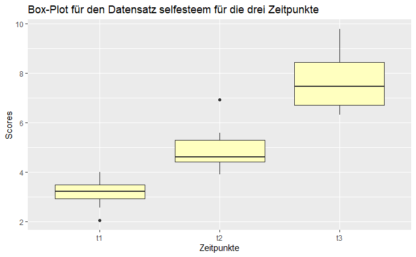

Beides zeigt uns, dass es durchaus Sinn macht ANOVA durchzuführen.

## 2.2 Hypothesentest

Jetzt führen wir den Hypothesentest mit der Funktion *anova_test* in einer Pipeline durch. Dabei verwenden wir die Funktion *get_anova_table*, um die Ergebnisse auf der Konsole auszugeben:

```r
aov.test <- selfesteem %>%
  anova_test(dv = score, wid = id, within = time)

get_anova_table(aov.test)
```

```
ANOVA Table (type III tests)

  Effect DFn DFd     F        p p<.05   ges
1   time   2  18 55.47 2.01e-08     * 0.829
```

Der angegebene p-Wert führt dazu, dass wir die Nullhypothese verwerfen.

## 2.3 Paarweise Vergleiche

Wir führen wieder paarweise Vergleiche durch, um zu untersuchen ob alle Zeitpunkte zu einer Veränderung führen. Dabei verwenden wir t-Tests, dabei achten wir natürlich darauf, dass wir einen gepaarten t-Test durchführen.

```r
(pwc <- selfesteem %>%
  pairwise_t_test(
    score ~ time,
    paired = TRUE,
    p.adjust.method = "bonferroni"
  ))
```

|  | .y. | group1 | group2 | n1 | n2 | statistic | df | p | p.adj | p.adj.signif |
| --- | --- | --- | --- | --- | --- | --- | --- | --- | --- | --- |
| 1 | score | t1 | t2 | 10 | 10 | -4.968 | 9 | 7.72e-04 | 2e-03 | ** |
| 2 | score | t1 | t3 | 10 | 10 | -13.228 | 9 | 3.34e-07 | 1e-06 | **** |
| 3 | score | t2 | t3 | 10 | 10 | -4.868 | 9 | 8.86e-04 | 3e-03 | ** |

Wir können das Tibble *pwc* (die Abkürzung steht für *pairweise comparison*) mit Hilfe von *ggplot2* ausgeben:

[figure not shown]

```r
pwc <- pwc %>%
  add_xy_position(x = "time")

ggplot(data=selfesteem, aes(x=time, y = score)) +
  geom_boxplot(fill="darkgoldenrod1", color="black") +
  stat_pvalue_manual(pwc, hide.ns=FALSE) +
  labs(
    title="Paarweise Vergleiche nach Tukey für den Datensatz selfesteem",
    x = "Zeitpunkte",
    y = "Scores"
  )
```

Wir erkennen gut, dass es signifikante Unterschiede zwischen den drei Zeitpunkten gibt.

# 3 Literaturverzeichnis

Datanovia. 2021. *Comparing Multiple Means in R*. https://www.datanovia.com/en/lessons/anova-in-r/.

Kassambara, Alboukadel. 2019. *Practical Statistics in R for Comparing Groups: Numerical Variables*. Independently published.